# Integration_2_cohorts

helena

02/04/2020

# Features extracted from the comparison of tolerant and non-tolerant patients

## St Louis cohort

For the patients from the St Louis cohort, I extract the CyTOF, metabo and transcriptomics features that had the same behaviour in both cohorts:

```r
ft_integ_louis <- readRDS("~/Documents/VIB/Projects/Integrative_Paris/Integrative/outputs/data/integ/cyt_met_rna_beh_features.RDS")
```

I extract the metadata (age, gender, …) for the St Louis cohort

```
## [1] "0"
```

```
## [1] "1"
```

```
##   Id.Cryostem.R              GROUP GENDER        DOB        DOG gender_comp
## 1         R1503   primary_tolerant      M 1991-05-19 2014-01-02          FM
## 2         R2032 secondary_tolerant      M 1971-04-27 2014-04-22          MM
## 3         R1044   primary_tolerant      M 1992-03-07 2013-09-12          MM
## 4         R2798 secondary_tolerant      F 1983-12-14 2014-10-06          FF
## 5          R346       non_tolerant      F 1965-01-08 2013-04-03          FF
## 6          R997 secondary_tolerant      F 1989-12-20 2013-12-05          FF
##   age_recip cmv_comp
## 1      8264       11
## 2     15701       00
## 3      7859       00
## 4     11254       11
## 5     17617       11
## 6      8751       11
```

I add the metadata information to my table for later:

```r
ft_louis <- left_join(ft_integ_louis,
                      recip_info_louis,
                      by = "Id.Cryostem.R")
```

## Cryostem cohort

For the patients from the Cryostem cohort, I extract the CyTOF, metabo and transcriptomics features that had the same behaviour in both cohorts:

```r
ft_integ_cryo <- readRDS("~/Documents/VIB/Projects/Integrative_Paris/Integrative/outputs/data/integ_national/cyt_met_rna_beh_features.RDS")
```

I extract the metadata (age, gender, …) for the Cryostem cohort

```
## [1] 1
```

```
## [1] 1
```

```
##   Gender   HOSPITAL DATEOFCYTOFEXPERIMENT              group gender_comp
## 1      F CHU Angers            15.09.2017       non_tolerant          MF
## 2      F CHU Angers            21.09.2017   primary_tolerant          FF
## 3      F CHU Angers            21.09.2017   primary_tolerant          FF
## 4      M CHU Angers            21.09.2017   primary_tolerant          MM
## 5      F CHU Angers            21.09.2017       non_tolerant          MF
## 6      F CHU Angers            21.09.2017 secondary_tolerant          FF
##   age_recip cmv_comp
## 1     19529       11
## 2     16936       11
## 3     12009       00
## 4     22713      0NA
## 5     17236       00
## 6     12793       00
```

I add the metadata information to my table for later:

```r
recip_info_cryo <- recip_info_cryo %>%
  mutate(Id.Cryostem.R = CyTOF.Name)

ft_cryo <- left_join(ft_integ_cryo,
                      recip_info_cryo,
                      by = "Id.Cryostem.R")
```

## Both cohorts

I can now merge St Louis and Cryostem patients into one big table, and perform PCA:

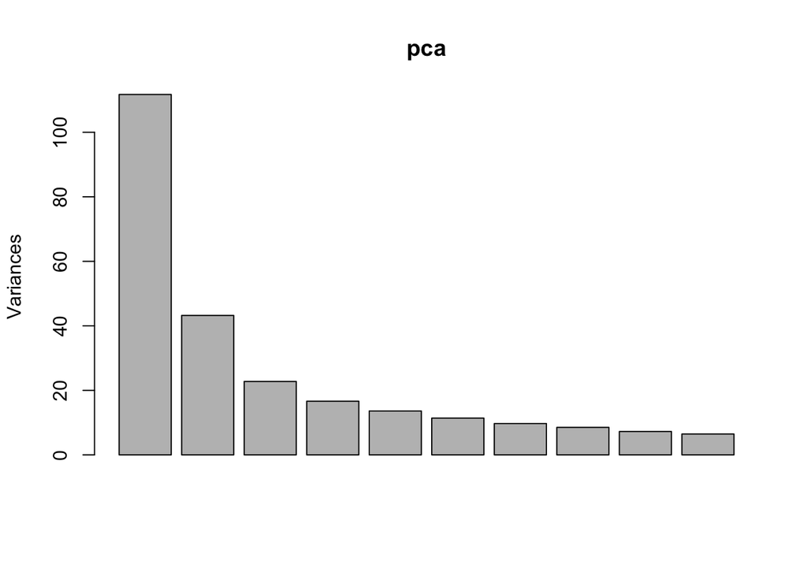

```r
pca <- prcomp(ft_integ_2_cohorts, center = TRUE, scale. = TRUE)
plot(pca)
```

And plot the patients coloured per group:

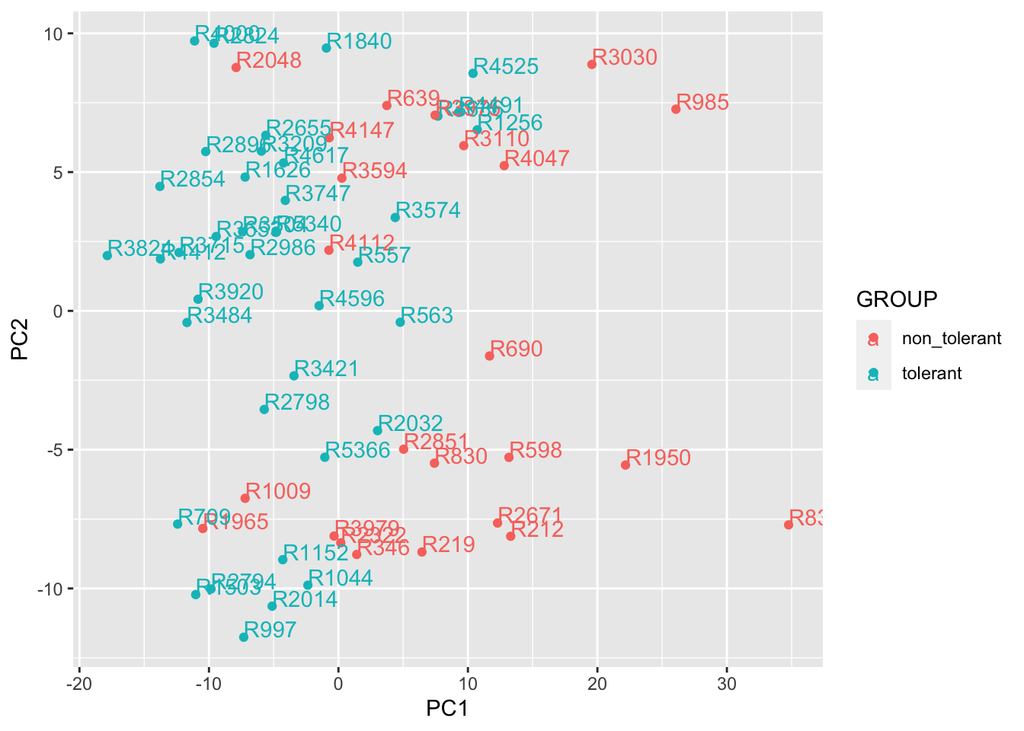

A large number of the non-tolerant patients are on the right of this PCA. Among these non-tolerant patients, we retrieve the patients that we had already identified as special in the CyTOF data of the St-Louis cohort: R836, R219, R830, R598, R690

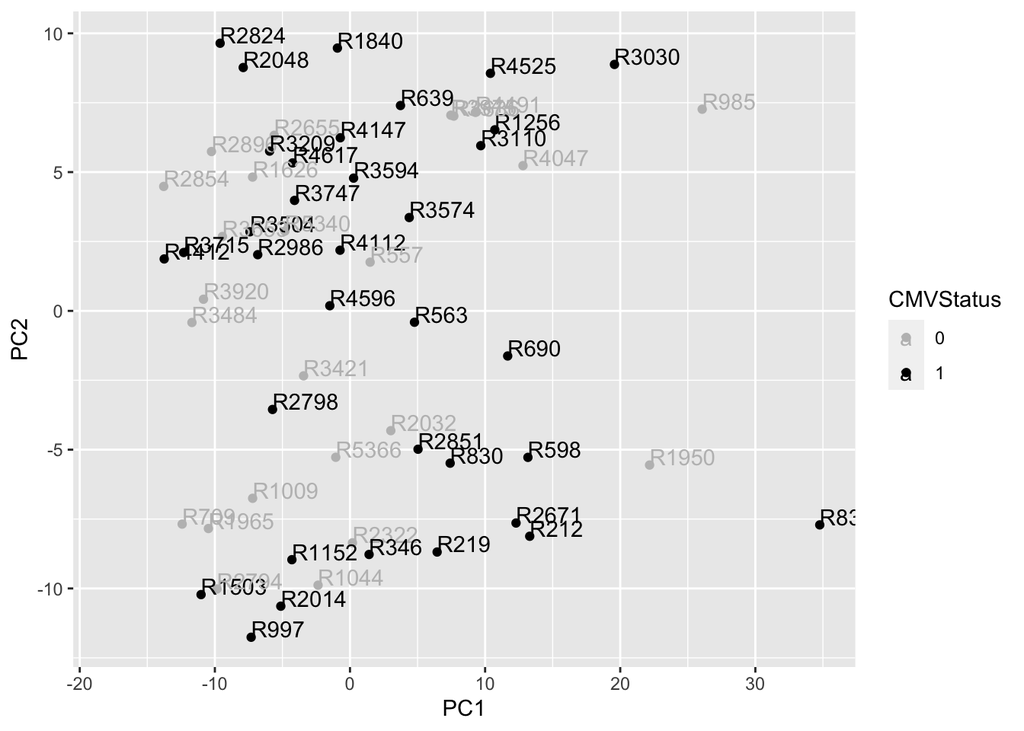

```r
ggplot(ft_2, aes(x = PC1, y = PC2, col = CMVStatus), label = Id.Cryostem.R) +
  geom_point() +
  geom_text(aes(label=Id.Cryostem.R),hjust=0, vjust=0) +
  scale_color_manual(breaks = c("0", "1", "NA"),
                     values = c("grey", "black", "violet"))
```

Many of these patients have CMV. We can see which CyTOF, metabo and transcriptomics features are pushing the patients to the right on the PCA:

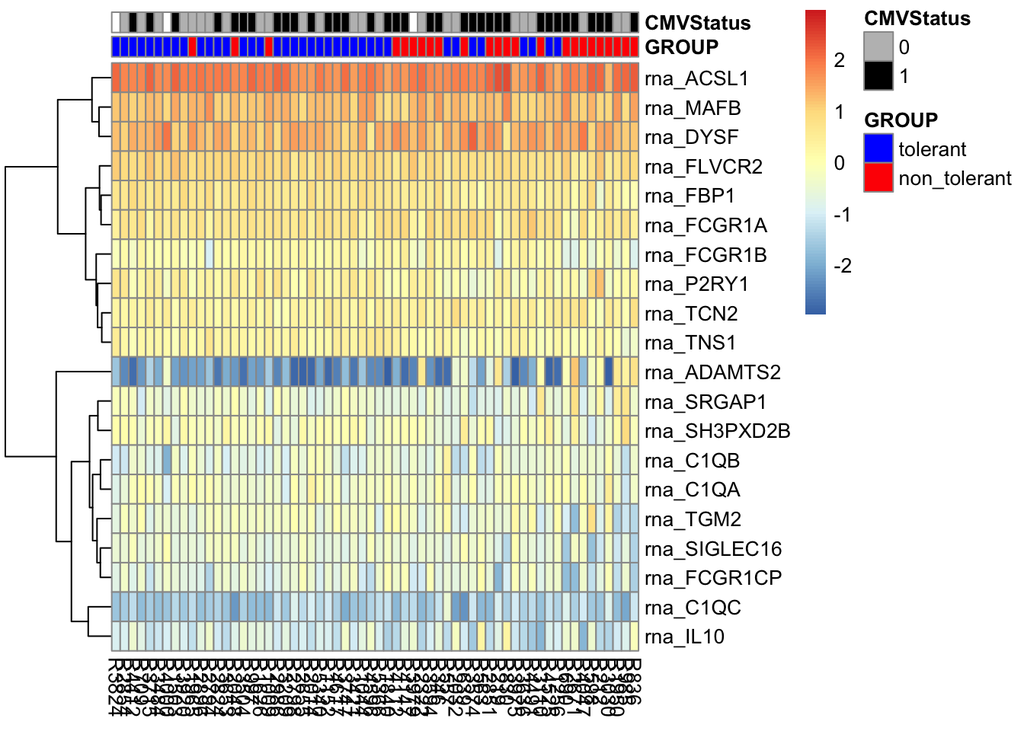

### Different approach : clustering

We can use a different approach by clustering the patients into 2 clusters based on ther CyTOF, metabo and transcriptomics features.

How were the patients split? In cluster 1, we have more non-tolerant patients, of which a high majority has CMV. In cluster 2, there are mainly tolerant patients, and the CMV is 50/50

```r
cl1 <- rownames(ft_2_km)[which(km$cluster == 1)]
cl2 <- rownames(ft_2_km)[which(km$cluster == 2)]

ft_km <- ft_2 %>%
  mutate(clustering = km$cluster)
table(ft_km[,c("GROUP", "CMVStatus", "clustering")])
```

```
## , , clustering = 1
##
##               CMVStatus
## GROUP           0  1
##   non_tolerant  4 11
##   tolerant      3  4
##
## , , clustering = 2
##
##               CMVStatus
## GROUP           0  1
##   non_tolerant  3  5
##   tolerant     14 15
```

Which variables differ the most between the two clusters?

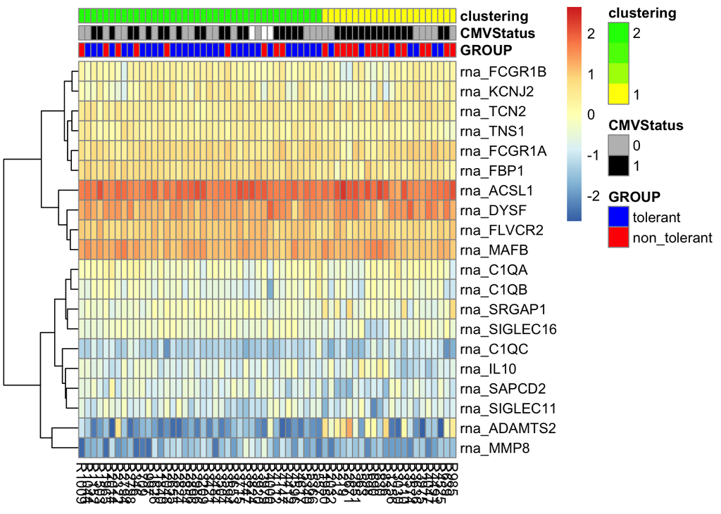

## CyTOF alone:

We can do the same analyis but focusing only on the CyTOF features. I extract the 24 features for the St Louis cohort

```
## [1] "0"
```

```
## [1] "1"
```

```
##   Id.Cryostem.R              GROUP GENDER        DOB        DOG lastfollowup
## 1         R2498       non_tolerant      F 1954-12-05 2014-08-06        42926
## 2         R1503   primary_tolerant      M 1991-05-19 2014-01-02        42622
## 3         R2032 secondary_tolerant      M 1971-04-27 2014-04-22        42985
## 4         R1044   primary_tolerant      M 1992-03-07 2013-09-12        41122
## 5         R2798 secondary_tolerant      F 1983-12-14 2014-10-06        43042
## 6          R346       non_tolerant      F 1965-01-08 2013-04-03        43088
##   gender_comp age_recip
## 1          FF     21794
## 2          FM      8264
## 3          MM     15701
## 4          MM      7859
## 5          FF     11254
## 6          FF     17617
```

And for the Cryostem cohort:

```
## [1] 1
```

```
## [1] 1
```

```
##   Gender   HOSPITAL DATEOFCYTOFEXPERIMENT              group gender_comp
## 1      F CHU Angers            15.09.2017       non_tolerant          MF
## 2      F CHU Angers            21.09.2017   primary_tolerant          FF
## 3      F CHU Angers            21.09.2017   primary_tolerant          FF
## 4      M CHU Angers            21.09.2017   primary_tolerant          MM
## 5      F CHU Angers            21.09.2017       non_tolerant          MF
## 6      F CHU Angers            21.09.2017 secondary_tolerant          FF
##   age_recip cmv_comp
## 1     19529       11
## 2     16936       11
## 3     12009       00
## 4     22713      0NA
## 5     17236       00
## 6     12793       00
```

I can then merge the two cohorts into one dataset:

```r
if(all(colnames(ft_recip_cyto_louis) == colnames(ft_recip_cyto_cryo))){
  ft_cyto <- rbind(ft_recip_cyto_louis,
                   ft_recip_cyto_cryo)
}
```

And apply PCA to the data:

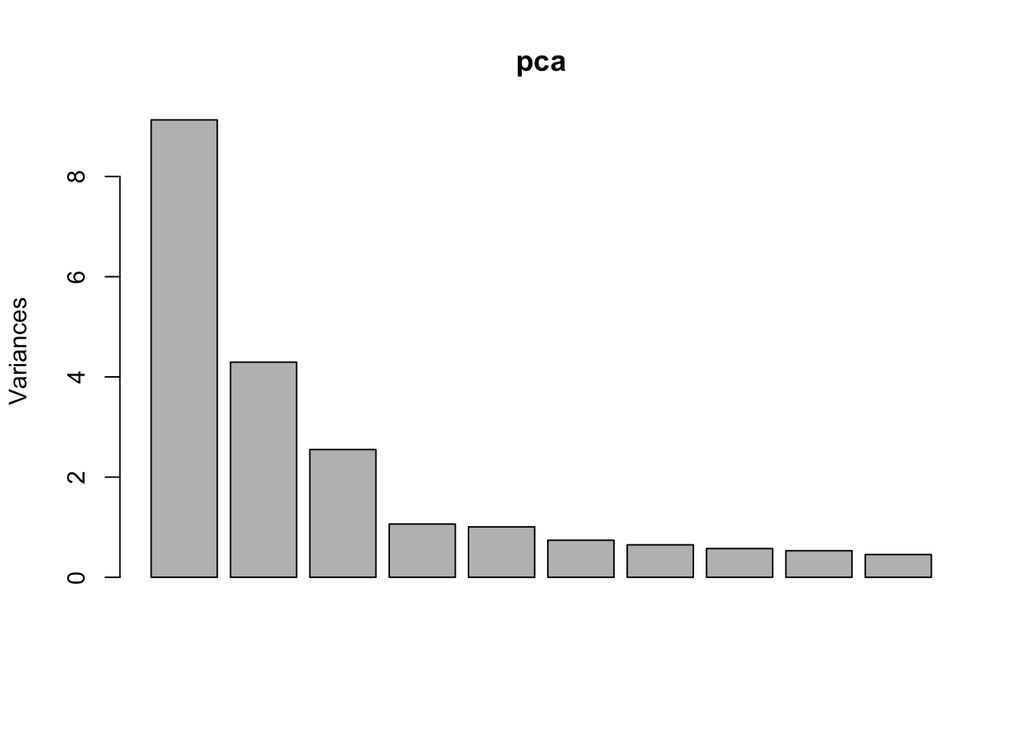

```r
pca <- prcomp(ft_cyto, center = TRUE, scale. = TRUE)
plot(pca)
```

We can plot the patients coloured per group:

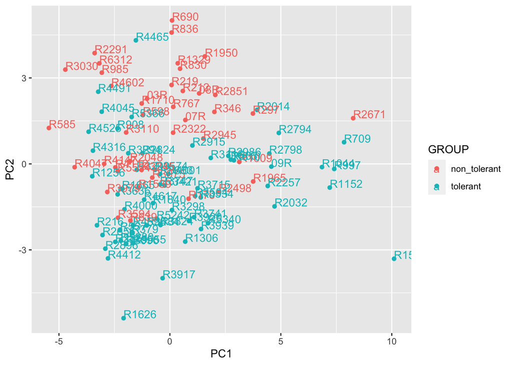

A large number of the non-tolerant patients are on the top of this PCA. Among these non-tolerant patients, we retrieve the patients that we had already identified as special in the CyTOF data of the St-Louis cohort: R836, R219, R830, R598, R690

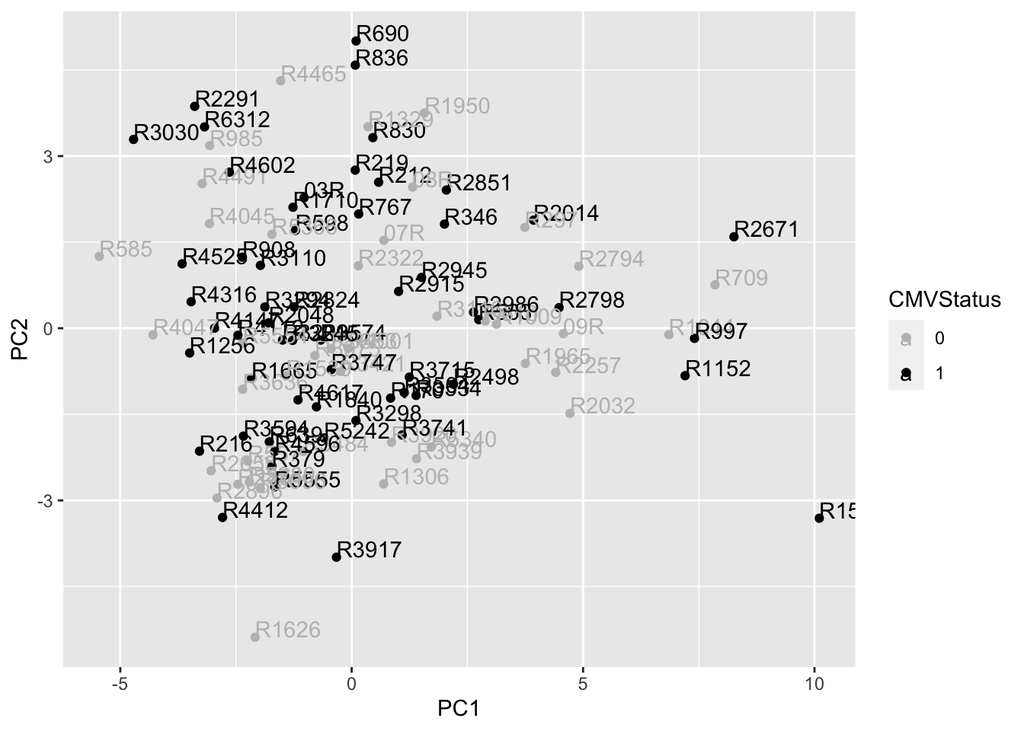

```r
ggplot(ft_2_cohorts, aes(x = PC1, y = PC2, col = CMVStatus), label = Id.Cryostem.R) +
  geom_point() +
  geom_text(aes(label=Id.Cryostem.R),hjust=0, vjust=0) +
  scale_color_manual(breaks = c("0", "1", "NA"),
                     values = c("grey", "black", "violet"))
```

Many of these patients have CMV. We can see which CyTOF features are pushing the patients to the top of the PCA:

[figure not shown]

### Different approach : clustering

We can use a different approach by clustering the patients into 2 clusters based on ther CyTOF features.

```r
cl1 <- rownames(ft_2_km)[which(km$cluster == 1)]
cl2 <- rownames(ft_2_km)[which(km$cluster == 2)]

ft_km <- ft_2_cohorts %>%
  mutate(clustering = km$cluster)
table(ft_km[,c("GROUP", "CMVStatus", "clustering")])
```

```
## , , clustering = 1
##
##               CMVStatus
## GROUP           0  1
##   non_tolerant  7 11
##   tolerant     10 12
##
## , , clustering = 2
##
##               CMVStatus
## GROUP           0  1
##   non_tolerant  7 15
##   tolerant     18 20
```

Which variables differ the most between the two clusters?

[figure not shown]